# Exploring the phylogenetic composition of microbiomes

### 5.4. Partitioning the tree by total variance explained

The previous results were ranked according to the factors that had the strongest correlation, as measured by effect size (F). We can also rank factors according to the total proportion of variance explained, by setting `choice` equal to `'var'`.

```r
pf_depth_var <- PhyloFactor(OTU.matrix, Tree, X = metadata, frmla = Data~Depth_m, nfactors = 5, ncores=2, stop.early = T, choice='var')
```

```
##
 1 factor completed in 0.415 minutes.    Estimated time of completion: 2018-06-18 17:18:58
```

```
##
 2 factors completed in 0.778 minutes.     Estimated time of completion: 2018-06-18 17:18:50
```

```
##
 3 factors completed in 1.12 minutes.     Estimated time of completion: 2018-06-18 17:18:46
```

```
##
 4 factors completed in 1.44 minutes.     Estimated time of completion: 2018-06-18 17:18:41
```

```
##
 5 factors completed in 1.77 minutes.     Estimated time of completion: 2018-06-18 17:18:39
```

```r
pf_depth_var
```

```
##        phylofactor object from function PhyloFactor
##        --------------------------------------------
## Method                    : glm
## Choice                    : var
## Formula                   : Data ~ Depth_m
## Number of species         : 4315
## Number of factors         : 5
## Frac Explained Variance   : 0.053
## Largest non-remainder bin : 259
## Number of singletons      : 0
## Paraphyletic Remainder    : 3455 species
##
## -------------------------------------------------------------
## Factor Table:
##                                 Group1                         Group2
## Factor 1 259 member Monophyletic clade 4056 member Monophyletic clade
## Factor 2 136 member Monophyletic clade 3920 member Paraphyletic clade
## Factor 3 212 member Monophyletic clade 3708 member Paraphyletic clade
## Factor 4 129 member Monophyletic clade 3579 member Paraphyletic clade
## Factor 5 124 member Monophyletic clade 3455 member Paraphyletic clade
##             ExpVar      F    Pr(>F)
## Factor 1 0.0176480 12.574 0.0164590
## Factor 2 0.0116130 23.402 0.0047250
## Factor 3 0.0094600 13.560 0.0142580
## Factor 4 0.0079415 44.897 0.0011203
## Factor 5 0.0063376 27.486 0.0033462
```

Note that when optimizing for total variance explained, PhyloFactor will tend to find bigger clades, as they represent a larger overall proportion of the data. The F-scores are lower in this case than for the smaller factors, which indicate that some members of the clade are not following the same linear relationship with depth.

We can see this, for examle, in the second PhyloFactor for the variance-paritioned tree. This factor represents a clade of Alphaproteobacteria, including the Rhodobacteraceae we found above:

```r
pf.taxa(pf_depth_var, taxonomy, factor=2)$group1
```

```
## [1] "Bacteria;Proteobacteria;Alphaproteobacteria;Rhizobiales;PS1_clade"
## [2] "Bacteria;Proteobacteria;Alphaproteobacteria;Alphaproteobacteria_unclassified;Alphaproteobacteria_unclassified;Alphaproteobacteria_unclassified"
## [3] "Bacteria;Proteobacteria;Alphaproteobacteria;Rhizobiales;Rhizobiales_unclassified;Rhizobiales_unclassified"
## [4] "Bacteria;Proteobacteria;Alphaproteobacteria;Rhodobacterales;Rhodobacteraceae;Frigidibacter"
## [5] "Bacteria;Proteobacteria;Alphaproteobacteria;Rhodobacterales;Rhodobacteraceae;Rhodobacteraceae_unclassified"
## [6] "Bacteria;Proteobacteria;Alphaproteobacteria;Rhodobacterales;Rhodobacteraceae;Amylibacter"
## [7] "Bacteria;Proteobacteria;Alphaproteobacteria;Rhodobacterales;Rhodobacteraceae;Octadecabacter"
## [8] "Bacteria;Proteobacteria;Alphaproteobacteria;Rhodobacterales;Rhodobacteraceae;Litoreibacter"
## [9] "Bacteria;Proteobacteria;Alphaproteobacteria;Rhizobiales;Phyllobacteriaceae"
```

As you can see by plotting the ILR abundances of this entire clade against depth, the correlation is not as tight across the full range. Other bacteria in this clade may be especially more prominant at the very shallowest depths:

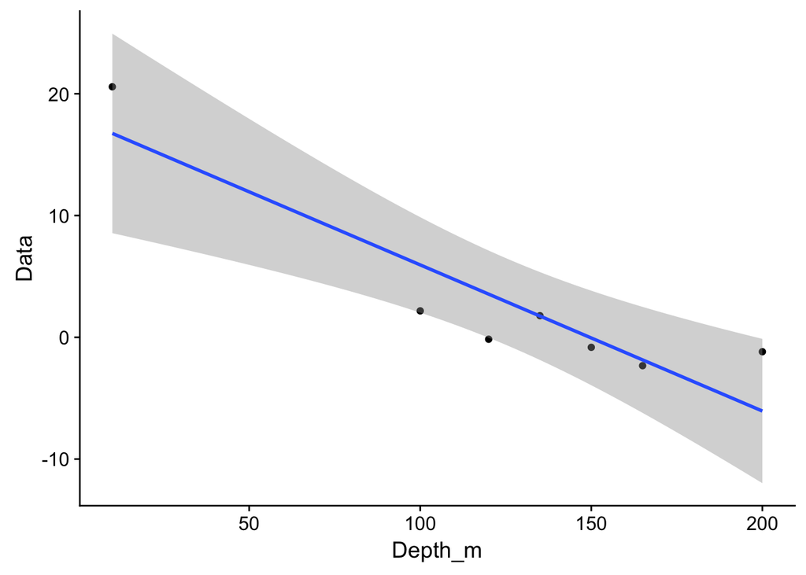

```r
s_pf_depth.var.summary.2 <- summary(pf_depth_var, factor=2)

ggplot(s_pf_depth.var.summary.2$data, aes(x = Depth_m, y = Data)) +
geom_point() +
geom_smooth(method='lm')
```

### 5.5. Comparing phylofactorization with different independent variables

Let’s combine all we’ve practiced so far to visualize using PhyloFactorization how different clades of the bacterial phylogeny respond to changes in different variables in our dataset.

We can use the `cowplot` package to combine different ggplot elements to simultaneously illustrate the ILR-values for individual PhyloFactors and their location on the phylogeny. For this, we’ll just take the top three factors

First, we’ll write a short helper function to format the individual inset XY plots.

```r
inset_plot <- function(pf, factor, variable, color) {
  pf_s <- summary(pf, factor=factor)

  p <- ggplot(pf_s$data, aes_string(x = variable, y = 'Data')) +
        geom_point(color = color) +
        geom_abline(slope = coef(pf$models[[factor]])[2],
                    intercept = coef(pf$models[[factor]])[1])

  return(p)
}
```

Now we can perform a phylofactorization of the bacterial phylogeny with respect to different variables of interest. We’ll compare the bacterial groups responding to nitrate (NO3) and phosphate (PO4), two important and frequently limiting nutrients in oligotrophic environments. Let’s grab the top three factors for each, according to total variance explained.

```r
pf_NO3_var <- PhyloFactor(OTU.matrix, Tree, X = metadata, frmla = Data~NO3_uM, nfactors = 3, ncores=2, choice='var')
```

```
##
 1 factor completed in 0.427 minutes.    Estimated time of completion: 2018-06-18 17:20:18

 2 factors completed in 0.828 minutes.     Estimated time of completion: 2018-06-18 17:20:16

 3 factors completed in 1.21 minutes.     Estimated time of completion: 2018-06-18 17:20:14
```

```r
pf_PO4_var <- PhyloFactor(OTU.matrix, Tree, X = metadata, frmla = Data~PO4_uM, nfactors = 3, ncores=2, choice='var')
```

```
##
 1 factor completed in 0.433 minutes.    Estimated time of completion: 2018-06-18 17:21:33

 2 factors completed in 0.807 minutes.     Estimated time of completion: 2018-06-18 17:21:27

 3 factors completed in 1.16 minutes.     Estimated time of completion: 2018-06-18 17:21:25
```

For each PhyloFactor object, we can use the `cowplot` library to combine separate `ggplot2` panels into a publication-ready image, showing both individual factors locations on the tree, and their response (in ILR-transformed space) to each predictor variable.

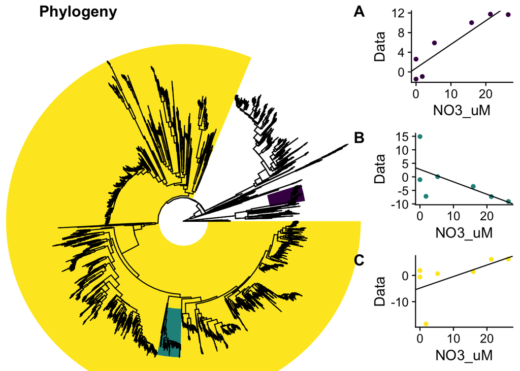

```r
# Draw the PhyloFactors on the phylogeny
NO3_tree = pf.tree(pf_NO3_var)

# Make inset plots for each factor
g1_NO3 = inset_plot(pf_NO3_var,                  # The PhyloFactor object we just calculated
                    1,                           # The first factor
                    'NO3_uM',                    # Plotting against the NO3_uM variable
                    NO3_tree$legend$colors[1])   # Use the color for this factor from the tree
g2_NO3 = inset_plot(pf_NO3_var, 2, 'NO3_uM', NO3_tree$legend$colors[2])
g3_NO3 = inset_plot(pf_NO3_var, 3, 'NO3_uM', NO3_tree$legend$colors[3])

# Draw the inset plots composed with the PhyloFactor phylogeny
ggdraw() +
  draw_plot(NO3_tree$ggplot,
            x = 0, y = 0.05, width = .7, height = .7,scale = 1.8) +
  draw_plot(g1_NO3, x = .7, y = .66, width = .3, height = .33) +
  draw_plot(g2_NO3, x = .7, y = .33, width = .3, height = .33) +
  draw_plot(g3_NO3, x = .7, y = 0, width = .3, height = .33) +
  draw_plot_label(label = c("Phylogeny", "A", "B","C"), size = 15,
                  x = c(0, 0.67, .67,.67), y = c(1, 1, 0.66,0.33))
```

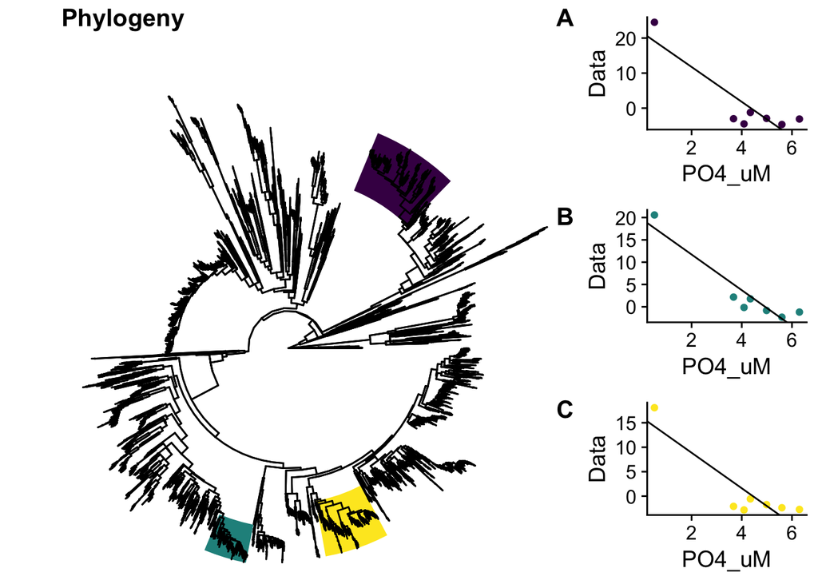

```r
# Repeat for the phosphate PhyloFactors
PO4_tree = pf.tree(pf_PO4_var)

g1_PO4 = inset_plot(pf_PO4_var, 1, 'PO4_uM', PO4_tree$legend$colors[1])
g2_PO4 = inset_plot(pf_PO4_var, 2, 'PO4_uM', PO4_tree$legend$colors[2])
g3_PO4 = inset_plot(pf_PO4_var, 3, 'PO4_uM', PO4_tree$legend$colors[3])

ggdraw() +
  draw_plot(PO4_tree$ggplot,
            x = 0, y = 0.05, width = .7, height = .7,scale = 1.8) +
  draw_plot(g1_PO4, x = .7, y = .66, width = .3, height = .33) +
  draw_plot(g2_PO4, x = .7, y = .33, width = .3, height = .33) +
  draw_plot(g3_PO4, x = .7, y = 0, width = .3, height = .33) +
  draw_plot_label(label = c("Phylogeny", "A", "B","C"), size = 15,
                  x = c(0, 0.67, .67,.67), y = c(1, 1, 0.66,0.33))
```

### 5.6. Other visualizations using PhyloFactor: phylogenetic heatmaps

Heatmaps can help give us a better sense of how the data are actually distributed across samples and the tree. We can use the `pf.heatmap` function to draw both the tree (and highlight the relevant PhyloFactor partitions) and the (ILR-transformed) raw data for each tip:

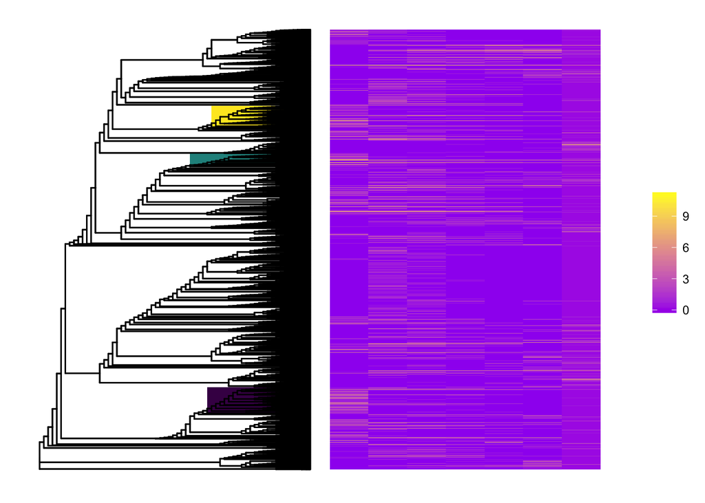

```r
pf.heatmap(pf_PO4_var,
           factors=1:3,
           column.order = order(metadata$PO4_uM),
           low='purple',
           high='yellow')
```

Heatmaps can also be used to illustrate the values predicted across the tree, using the linear models fit by PhyloFactorization above:

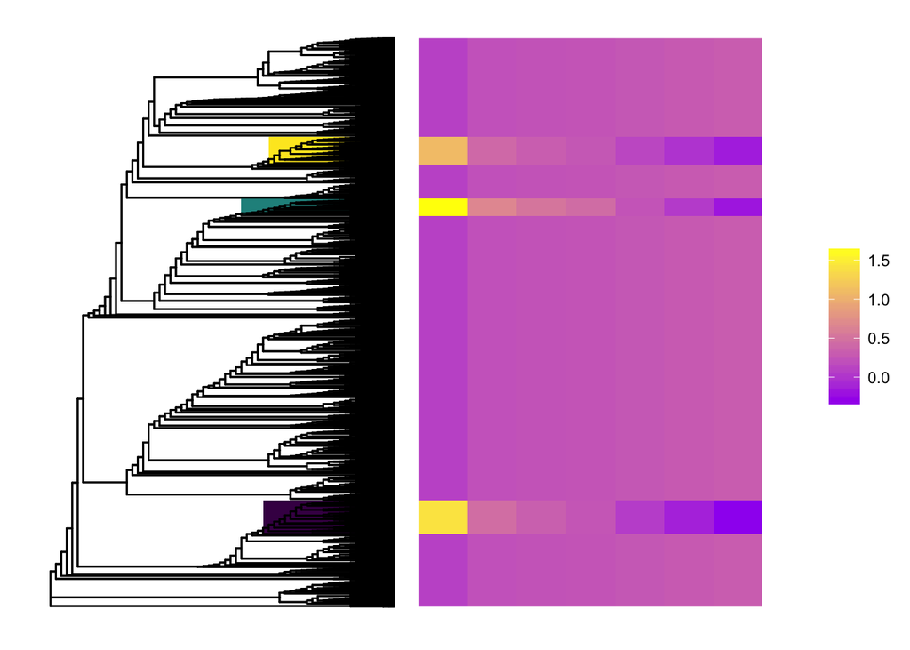

```r
preds <- predict(pf_PO4_var)

pf.heatmap(pf_PO4_var,
           factors=1:3,
           Data=preds,
           column.order = order(metadata$PO4_uM),
           low='purple',
           high='yellow')
```